# Analysis

## Table of contents

- Import data
- Model liking
- Survival analysis
- Hierarchical linear regression
- Exploratory analyses
- Race, class, and gender
- Textual analysis
- Output

## Import data

*Try making your own ggplot themes* Customize functions (hidden)

```r
nms <- dat %>%
  select_if(is.factor) %>%
  select(-matches("gender|race|major")) %>%
  names()

dat[,names(dat) %in% nms] <- lapply(dat[,names(dat) %in% nms],
                                    as.numeric)
```

## Quantitative analyses

Statistics notes:

- multilevel regressions are for dependency in groups within groups - hierarchical structure
- multiple regressions are for more than one predictor (use lm() with +)
- interactions are tested for using lm() with *
- try using ANOVA to compare multiple models as well as simple and complex models: `summary(anova(mod1, mod2))`
- how to analyze Likert scales? [Evidence indicates](https://statisticsbyjim.com/hypothesis-testing/analyze-likert-scale-data/) it may be ok to use regular T tests?? at least compared to nonparametric tests that don’t assume continuity
- try factor analysis with all of the survey items that look like they *might* measure the same construct.
- in regressions with multi-level categorical explanatories, do levels have to be ordinal? I think I need to transform the model_race, p_race, and major measures so that they are binary coded?
- try Mann-Whitney or Kruskal Wallis because persist and dropoff are not normally distributed outcomes
- I am going to try hierarchical linear regression a la Leaper et al.
- ANOVA assumptions violated: persistence is not normal. what to do? also test for homogeneity of variance?

### Model liking

Maybe people liked a certain gender or race better overall ?

Since race is categorical, but model rating is quantitative, let’s try a 2-way ANOVA.

```r
summary(aov(lm(model_score ~ model_gender * model_race, data = dat)))
```

```
##                         Df Sum Sq Mean Sq F value Pr(>F)
## model_gender             1   2.28  2.2821   2.871 0.0949 .
## model_race               3   0.81  0.2714   0.341 0.7955
## model_gender:model_race  3   1.97  0.6582   0.828 0.4831
## Residuals               66  52.47  0.7949
## ---
## Signif. codes:  0 '***' 0.001 '**' 0.01 '*' 0.05 '.' 0.1 ' ' 1
```

Participants did not have a significant preference for any race or gender overall. This is expected.

Interestingly, we did not find an intersectional effect for consciously reported liking.

## Survival analysis

*Poisson (survival curve).* [Rhodes et al open science framework/portal](https://osf.io/39x7w/)

```r
dat$dg <- ifelse(dat$dg == TRUE, "gender mismatch", "gender match")
dat$dg <- factor(dat$dg, levels = unique(dat$dg))

dat$dr <- ifelse(dat$dr == TRUE, "race mismatch", "race match")
dat$dr <- factor(dat$dr, levels = unique(dat$dr))

dat$censor <- ifelse(dat$persist < 7, 1, 0)
```

```r
summary(glm(persist ~ dr * dg, family = "poisson", data = dat))
```

```
##
## Call:
## glm(formula = persist ~ dr * dg, family = "poisson", data = dat)
##
## Deviance Residuals:
##     Min       1Q   Median       3Q      Max
## -2.6247  -1.5541  -0.2449   1.1567   1.6784
##
## Coefficients:
##                                Estimate Std. Error z value Pr(>|z|)
## (Intercept)                     1.54881    0.11180  13.853   <2e-16 ***
## drrace mismatch                -0.07441    0.15668  -0.475   0.6348
## dggender match                 -0.31205    0.16920  -1.844   0.0651 .
## drrace mismatch:dggender match  0.28457    0.22900   1.243   0.2140
## ---
## Signif. codes:  0 '***' 0.001 '**' 0.01 '*' 0.05 '.' 0.1 ' ' 1
##
## (Dispersion parameter for poisson family taken to be 1)
##
##     Null deviance: 141.41  on 73  degrees of freedom
## Residual deviance: 137.67  on 70  degrees of freedom
## AIC: 370.04
##
## Number of Fisher Scoring iterations: 5
```

```r
surv_obj <- Surv(dat$persist, dat$censor)
surv_obj
```

```
##  [1] 7+ 7+ 1  7+ 1  5  2  4  2  3  7+ 1  5  7+ 7+ 3  7+ 3  1  1  1  7+ 1  7+ 5
## [26] 7+ 7+ 1  7+ 0  4  1  6  1  1  7+ 4  1  7+ 7+ 7+ 1  7+ 1  7+ 1  7+ 1  7+ 1
## [51] 1  7+ 1  3  3  7+ 7+ 7+ 7+ 6  2  4  4  1  7+ 7+ 3  7+ 7+ 7+ 3  4  1  1
```

```r
surv_mod <- coxph(surv_obj ~ dg * dr, data = dat)
summary(surv_mod)
```

```
## Call:
## coxph(formula = surv_obj ~ dg * dr, data = dat)
##
##   n= 74, number of events= 44
##
##                                    coef exp(coef) se(coef)      z Pr(>|z|)
## dggender match                  0.63211   1.88157  0.42799  1.477    0.140
## drrace mismatch                 0.08603   1.08984  0.45989  0.187    0.852
## dggender match:drrace mismatch -0.57143   0.56472  0.61150 -0.934    0.350
##
##                                exp(coef) exp(-coef) lower .95 upper .95
## dggender match                    1.8816     0.5315    0.8132     4.353
## drrace mismatch                   1.0898     0.9176    0.4425     2.684
## dggender match:drrace mismatch    0.5647     1.7708    0.1703     1.872
##
## Concordance= 0.571  (se = 0.046 )
## Likelihood ratio test= 2.79  on 3 df,   p=0.4
## Wald test            = 2.98  on 3 df,   p=0.4
## Score (logrank) test = 3.05  on 3 df,   p=0.4
```

```r
# summary(coxph(surv_obj ~ age + year + gpa +
#                           model_score + model_race + model_gender +
#                           mom_cs + dad_cs + cs_xp + pre_att_cs + pre_useful_act + pre_relevant_act +
#                           major + transfer + employ2 +
#                           dg * dr * p_gender * p_race,
#               data = dat))

surv_mod2 <- coxph(surv_obj ~ age + year + gpa +
                          model_score + model_race + model_gender + p_gender + p_race +
                          mom_cs + dad_cs + cs_xp + pre_att_cs + pre_useful_act + pre_relevant_act +
                          major + transfer + employ2 +
                          dg * dr,
              data = dat)
# summary(coxph(surv_obj ~ post_belonging + p_white + model_similar + likely_cs_course,
#               data = dat))

surv_tab <- as.data.frame(coef(summary(surv_mod2)))
surv_tab
```

```
##                                        coef    exp(coef)     se(coef)
## age                             0.100851589 1.106112e+00    0.1415632
## year                           -0.807966860 4.457634e-01    0.4051245
## gpa                             0.875373774 2.399772e+00    1.0287097
## model_score                    -0.016070158 9.840583e-01    0.3478284
## model_raceblack                 0.193460493 1.213441e+00    1.3580164
## model_racelatino               -0.347050247 7.067698e-01    1.0959826
## model_raceasian                -0.536678381 5.846871e-01    1.4076741
## model_genderfemale              0.569281107 1.766996e+00    0.6451367
## p_genderfemale                 -1.397532579 2.472062e-01    0.5714854
## p_racewhite                     0.198964779 1.220139e+00    1.2064599
## p_racelatino                    0.856388824 2.354642e+00    1.4371443
## p_raceblack                     0.482358885 1.619891e+00    1.3856513
## p_raceunknown                   0.855851225 2.353377e+00    0.7705310
## mom_cs                         -0.658472504 5.176414e-01    0.2283283
## dad_cs                         -0.093319856 9.109021e-01    0.1981595
## cs_xp                           0.371052524 1.449259e+00    0.5090311
## pre_att_cs                      0.008573151 1.008610e+00    0.2200402
## pre_useful_act                  0.099489511 1.104607e+00    0.3310584
## pre_relevant_act               -0.639002220 5.278188e-01    0.3765588
## majorother                     18.245242049 8.390888e+07 3783.6621744
## majorpsychobiology             17.505215687 4.003304e+07 3783.6621738
## majormicrobiology              17.949456173 6.242374e+07 3783.6623809
## majorcognitive science         19.001503834 1.787509e+08 3783.6622302
## majorpsychology                18.601702703 1.198441e+08 3783.6622415
## majorneuroscience              18.984495665 1.757364e+08 3783.6623255
## majorbiology                   16.705117473 1.798624e+07 3783.6622774
## transfer                        0.579471640 1.785095e+00    0.7972602
## employ2                         0.105095932 1.110817e+00    0.1511383
## dggender match                  1.047016076 2.849137e+00    0.8639705
## drrace mismatch                 0.550931808 1.734869e+00    1.2258221
## dggender match:drrace mismatch -1.410581469 2.440014e-01    1.4656287
##                                           z    Pr(>|z|)
## age                             0.712413847 0.476208543
## year                           -1.994366634 0.046112002
## gpa                             0.850943468 0.394800757
## model_score                    -0.046201391 0.963149734
## model_raceblack                 0.142458143 0.886718140
## model_racelatino               -0.316656700 0.751504108
## model_raceasian                -0.381251860 0.703016371
```

[output cut: 9 more lines]

```
## pre_att_cs                      0.038961740 0.968920892
## pre_useful_act                  0.300519516 0.763780912
## pre_relevant_act               -1.696952124 0.089705712
## majorother                      0.004822112 0.996152526
## majorpsychobiology              0.004626527 0.996308579
## majormicrobiology               0.004743937 0.996214900
## majorcognitive science          0.005021987 0.995993051
## majorpsychology                 0.004916322 0.996077358
## majorneuroscience               0.005017492 0.995996637
## majorbiology                    0.004415066 0.996477299
## transfer                        0.726828769 0.467330857
## employ2                         0.695362801 0.486827966
## dggender match                  1.211865602 0.225563831
## drrace mismatch                 0.449438631 0.653115269
## dggender match:drrace mismatch -0.962441222 0.335828015
```

```r
#Break it down by gender to report and graph

ydg <- dat %>%
  filter(dg == "gender mismatch")
ndg <-dat %>%
  filter(dg == "gender match")

#Gender mismatch
surv_obj1<-Surv(time = ydg$persist, event = ydg$censor)
surv_obj1
```

```
##  [1] 7+ 7+ 4  2  7+ 1  7+ 7+ 1  7+ 1  7+ 1  7+ 4  1  7+ 4  7+ 1  7+ 1  7+ 1  1
## [26] 7+ 3  7+ 7+ 6  4  7+ 7+ 3  4  1
```

```r
fit1<-survfit(surv_obj1 ~ dr, data = ydg)
summary(fit1)
```

```
## Call: survfit(formula = surv_obj1 ~ dr, data = ydg)
##
##                 dr=race match
##  time n.risk n.event survival std.err lower 95% CI upper 95% CI
##     1     17       4    0.765   0.103        0.587        0.995
##     4     13       5    0.471   0.121        0.284        0.779
##
##                 dr=race mismatch
##  time n.risk n.event survival std.err lower 95% CI upper 95% CI
##     1     19       6    0.684   0.107        0.504        0.929
##     2     13       1    0.632   0.111        0.448        0.890
##     3     12       2    0.526   0.115        0.344        0.806
##     6     10       1    0.474   0.115        0.295        0.761
```

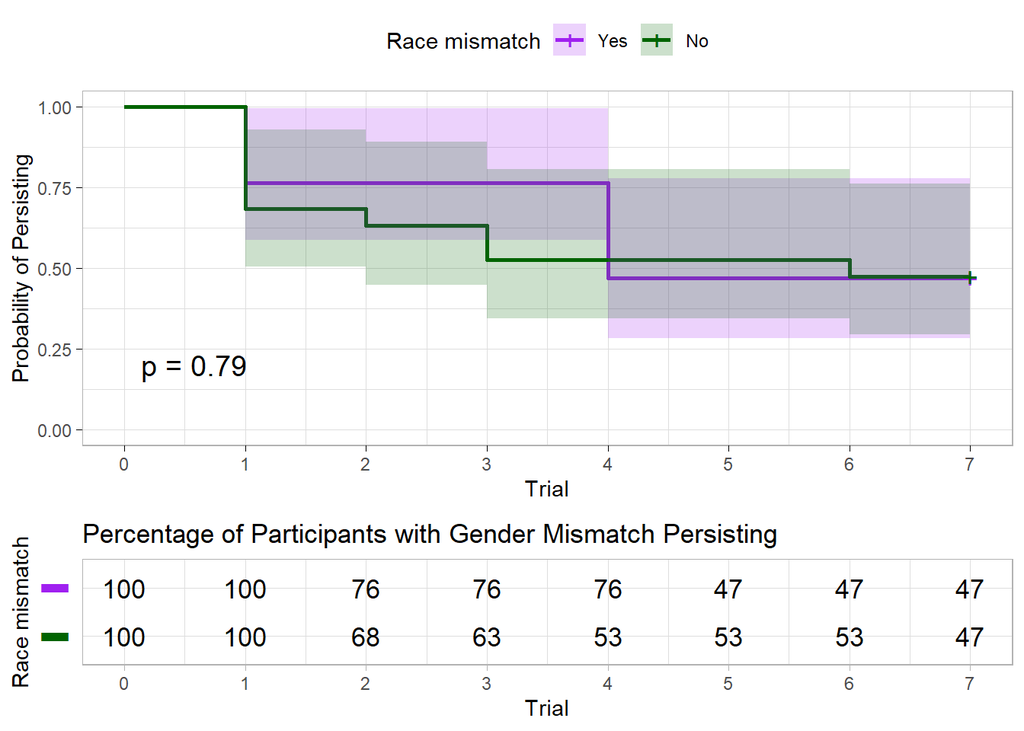

```r
graph1<-ggsurvplot(fit1,
                       data = ydg,
                       palette =  c("purple", "darkgreen"),
                       pval = TRUE,
                       conf.int = TRUE,
                       conf.int.alpha = .20,
                       break.time.by = 1,
                       risk.table = "percentage",
                       conf.int.style = "ribbon",
                       legend.title = "Race mismatch",
                       legend.labs = c("Yes", "No"),
                       xlab = "Trial",
                       ylab = "Probability of Persisting",
                       risk.table.title = "Percentage of Participants with Gender Mismatch Persisting",
                       ggtheme = theme_light(),
                       risk.table.y.text.col = T,
                       risk.table.y.text = FALSE,
                       risk.table.height = .30)
graph1
```

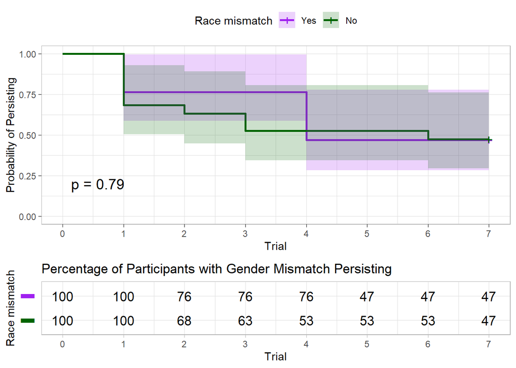

```r
print(graph1)
```

```r
surv_summary(fit1)
```

```
##   time n.risk n.event n.censor      surv   std.err     upper     lower
## 1    1     17       4        0 0.7647059 0.1345346 0.9954294 0.5874601
## 2    4     13       5        0 0.4705882 0.2572479 0.7791317 0.2842309
## 3    7      8       0        8 0.4705882 0.2572479 0.7791317 0.2842309
## 4    1     19       6        0 0.6842105 0.1558573 0.9286578 0.5041082
## 5    2     13       1        0 0.6315789 0.1752192 0.8903781 0.4480029
## 6    3     12       2        0 0.5263158 0.2176429 0.8063143 0.3435488
## 7    6     10       1        0 0.4736842 0.2418254 0.7609061 0.2948810
## 8    7      9       0        9 0.4736842 0.2418254 0.7609061 0.2948810
##             strata            dr
## 1    dr=race match    race match
## 2    dr=race match    race match
## 3    dr=race match    race match
## 4 dr=race mismatch race mismatch
## 5 dr=race mismatch race mismatch
## 6 dr=race mismatch race mismatch
## 7 dr=race mismatch race mismatch
## 8 dr=race mismatch race mismatch
```

```r
res1<-coxph(surv_obj1 ~ dr, data = ydg)
summary(res1)
```

```
## Call:
## coxph(formula = surv_obj1 ~ dr, data = ydg)
##
##   n= 36, number of events= 19
##
##                    coef exp(coef) se(coef)     z Pr(>|z|)
## drrace mismatch 0.09445   1.09905  0.46025 0.205    0.837
##
##                 exp(coef) exp(-coef) lower .95 upper .95
## drrace mismatch     1.099     0.9099    0.4459     2.709
##
## Concordance= 0.526  (se = 0.066 )
## Likelihood ratio test= 0.04  on 1 df,   p=0.8
## Wald test            = 0.04  on 1 df,   p=0.8
## Score (logrank) test = 0.04  on 1 df,   p=0.8
```

```r
test.ph1<-cox.zph(res1)
test.ph1
```

```
##        chisq df    p
## dr     0.411  1 0.52
## GLOBAL 0.411  1 0.52
```

```r
table1<-as.data.frame(coef(summary(res1)))
table1
```

```
##                       coef exp(coef)  se(coef)         z  Pr(>|z|)
## drrace mismatch 0.09444603   1.09905 0.4602475 0.2052071 0.8374104
```

```r
#Gender match
surv_obj2<-Surv(time = ndg$persist, event = ndg$censor)
surv_obj2
```

```
##  [1] 7+ 1  1  5  2  3  5  7+ 3  3  1  1  7+ 5  7+ 0  6  1  1  1  7+ 7+ 1  7+ 7+
## [26] 1  1  3  7+ 7+ 2  4  1  7+ 3  7+ 7+ 1
```

```r
fit2<-survfit(surv_obj2 ~ dr, data = ndg)
summary(fit1)
```

```
## Call: survfit(formula = surv_obj1 ~ dr, data = ydg)
##
##                 dr=race match
##  time n.risk n.event survival std.err lower 95% CI upper 95% CI
##     1     17       4    0.765   0.103        0.587        0.995
##     4     13       5    0.471   0.121        0.284        0.779
##
##                 dr=race mismatch
##  time n.risk n.event survival std.err lower 95% CI upper 95% CI
##     1     19       6    0.684   0.107        0.504        0.929
##     2     13       1    0.632   0.111        0.448        0.890
##     3     12       2    0.526   0.115        0.344        0.806
##     6     10       1    0.474   0.115        0.295        0.761
```

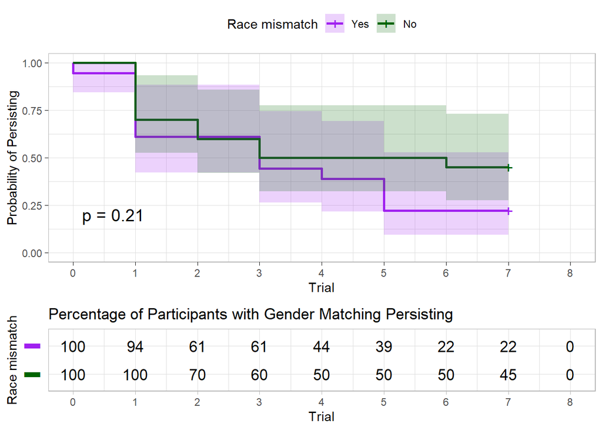

```r
graph2<-ggsurvplot(fit2, data = ndg,
                   palette =  c("purple", "darkgreen"),
                   pval = TRUE,
                   conf.int = TRUE,
                   conf.int.alpha = .20,
                   break.time.by = 1,
                   risk.table = "percentage",
                   conf.int.style = "ribbon",
                   legend.title = "Race mismatch",
                   legend.labs = c("Yes", "No"),
                   xlab = "Trial",
                   ylab = "Probability of Persisting",
                   risk.table.title = "Percentage of Participants with Gender Matching Persisting",
                   ggtheme = theme_light(),
                   risk.table.y.text = FALSE,
                   risk.table.height = .30)

graph2
```

```r
res2<-coxph(surv_obj2 ~ dr, data = ndg)
summary(res2)
```

```
## Call:
## coxph(formula = surv_obj2 ~ dr, data = ndg)
##
##   n= 38, number of events= 25
##
##                    coef exp(coef) se(coef)      z Pr(>|z|)
## drrace mismatch -0.4906    0.6123   0.4047 -1.212    0.225
##
##                 exp(coef) exp(-coef) lower .95 upper .95
## drrace mismatch    0.6123      1.633     0.277     1.353
##
## Concordance= 0.561  (se = 0.059 )
## Likelihood ratio test= 1.48  on 1 df,   p=0.2
## Wald test            = 1.47  on 1 df,   p=0.2
## Score (logrank) test = 1.5  on 1 df,   p=0.2
```

```r
table2<-as.data.frame(coef(res2))
table2
```

```
##                 coef(res2)
## drrace mismatch -0.4905553
```

```r
test.phb<-cox.zph(res2)
test.phb
```

```
##        chisq df    p
## dr     0.594  1 0.44
## GLOBAL 0.594  1 0.44
```

```r
#Bring graphs together

splots<-list(graph1, graph2)

Figure1<-arrange_ggsurvplots(splots, print = TRUE, ncol = 2, nrow = 1, title = NA)

Figure1
```

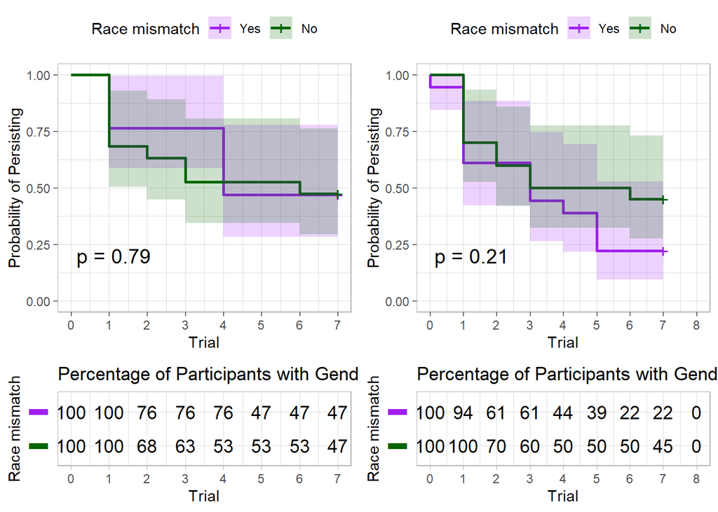

```r
print(Figure1)
```

Sample caption: “Figure 1. The survival curves for male and female participants by Language condition; p-values are from log-rank tests. Time 0 simply indicates that everyone had the opportunity to play the first trial of the game. As shown by the substantial drop from time 0 to time 1, many children chose to play no additional trials of the game after the four experimenter-controlled trials, and the drop in the number of children playing the science game was particularly pronounced among girls in the “Be Scientist” condition. Tests of the proportional hazards assumption confirmed that this assumption was met for the model as a whole and for the key Gender X Condition interaction, but violated for the subsumed main effect of Gender. One way of addressing this issue is to examine effects of condition separately by gender, as we have done here. Also, follow-up analyses including a Gender X Time interaction in the model, another recommended approach for addressing this issue (Fox & Weisberg, 2011), revealed an identical pattern of findings (see https://osf.io/p8f7w/ for full output of that model)."

*Check assumptions for Cox PH*

## Hierarchical linear regressions

Controlling for all possible alternative explanations that we collected data for, what are our main findings?

Note: in making models, I’ve seen many people enter a ton of variables as controls - what is the difference between an overfitted model and a well-controlled one?

The problem with the regular linear model is that we are violating the assumption of normally distributed outcome (persistence is bimodal). I would then use a poisson model to look at events, except that poisson models assume that dropoff events are independent. (? can we actually use poisson?) Thus, survival analysis may be best.

1. Base models for dropoff after first task

```r
#Make sure each model uses the same number of observations
dat <- filter(dat, !is.na(age), !is.na(gpa), !is.na(dad_cs), !is.na(mom_cs))

#Filter out participants whose race was unknown and participants whose race was Black, because we wanted to analyze differences based on participants' race, and these two groups are either not meaningful or not large enough, respectively, to be appropriately analyzed

#Not sure if it is better to do this, and drastically decrease sample size and power, since we are just controlling for participant race

#dat <- filter(dat, p_race != "unknown", p_race != "black")
#View(dat)
```

```r
dropoff_ctrls <- lm(dropoff ~ age + year + gpa,
                    data = dat)

dropoff_dem <- lm(dropoff ~ age + year + gpa +
                            model_score + model_race + model_gender + p_gender + p_race,
                  data = dat)

dropoff_xp <- lm(dropoff ~ age + year + gpa +
                            model_score + model_race + model_gender + p_gender + p_race +
                            mom_cs + dad_cs + cs_xp + pre_att_cs + pre_useful_act + pre_relevant_act,
                 data = dat)

dropoff_req <- lm(dropoff ~ age + year + gpa +
                            model_score + model_race + model_gender + p_gender + p_race +
                            mom_cs + dad_cs + cs_xp + pre_att_cs + pre_useful_act + pre_relevant_act +
                            major + transfer + employ2,
                  data = dat)
```

1. Condition

```r
dropoff_condition <- lm(dropoff ~ age + year + gpa +
                                  model_score + model_race + model_gender + p_gender + p_race +
                                  mom_cs + dad_cs + cs_xp + pre_att_cs + pre_useful_act + pre_relevant_act +
                                  major + transfer + employ2 +
                                  dr * dg,
                                  data = dat)

anova(dropoff_ctrls, dropoff_dem, dropoff_xp, dropoff_req, dropoff_condition)
```

```
## Analysis of Variance Table
##
## Model 1: dropoff ~ age + year + gpa
## Model 2: dropoff ~ age + year + gpa + model_score + model_race + model_gender +
##     p_gender + p_race
## Model 3: dropoff ~ age + year + gpa + model_score + model_race + model_gender +
##     p_gender + p_race + mom_cs + dad_cs + cs_xp + pre_att_cs +
##     pre_useful_act + pre_relevant_act
## Model 4: dropoff ~ age + year + gpa + model_score + model_race + model_gender +
##     p_gender + p_race + mom_cs + dad_cs + cs_xp + pre_att_cs +
##     pre_useful_act + pre_relevant_act + major + transfer + employ2
## Model 5: dropoff ~ age + year + gpa + model_score + model_race + model_gender +
##     p_gender + p_race + mom_cs + dad_cs + cs_xp + pre_att_cs +
##     pre_useful_act + pre_relevant_act + major + transfer + employ2 +
##     dr * dg
##   Res.Df     RSS Df Sum of Sq      F Pr(>F)
## 1     63 12.7063
## 2     53 10.6178 10   2.08853 1.0390 0.4327
## 3     47  9.3197  6   1.29804 1.0763 0.3953
## 4     38  7.4774  9   1.84233 1.0184 0.4447
## 5     35  7.0352  3   0.44219 0.7333 0.5392
```

```r
summary(dropoff_condition)
```

```
##
## Call:
## lm(formula = dropoff ~ age + year + gpa + model_score + model_race +
##     model_gender + p_gender + p_race + mom_cs + dad_cs + cs_xp +
##     pre_att_cs + pre_useful_act + pre_relevant_act + major +
##     transfer + employ2 + dr * dg, data = dat)
##
## Residuals:
##      Min       1Q   Median       3Q      Max
## -0.63356 -0.25872 -0.00758  0.22782  0.71315
##
## Coefficients:
##                                Estimate Std. Error t value Pr(>|t|)
## (Intercept)                    -0.88710    1.17464  -0.755   0.4552
## age                             0.03433    0.03718   0.923   0.3622
## year                           -0.06873    0.10465  -0.657   0.5157
## gpa                             0.20740    0.24742   0.838   0.4076
## model_score                    -0.04966    0.08888  -0.559   0.5800
## model_raceblack                 0.24852    0.33306   0.746   0.4605
## model_racelatino                0.03755    0.25702   0.146   0.8847
## model_raceasian                -0.21610    0.36993  -0.584   0.5629
## model_genderfemale              0.18691    0.17649   1.059   0.2968
## p_genderfemale                 -0.27760    0.16161  -1.718   0.0947 .
## p_racewhite                     0.12690    0.27668   0.459   0.6493
## p_racelatino                    0.04977    0.36499   0.136   0.8923
## p_raceblack                     0.56992    0.46071   1.237   0.2243
## p_raceunknown                   0.20301    0.22658   0.896   0.3764
## mom_cs                         -0.05759    0.06346  -0.907   0.3704
## dad_cs                         -0.03158    0.06288  -0.502   0.6186
## cs_xp                           0.12991    0.14973   0.868   0.3915
## pre_att_cs                     -0.06330    0.06885  -0.919   0.3642
## pre_useful_act                  0.02340    0.10059   0.233   0.8174
## pre_relevant_act               -0.07531    0.08988  -0.838   0.4078
## majorother                      0.37105    0.31957   1.161   0.2535
## majorpsychobiology              0.10254    0.32251   0.318   0.7524
## majormicrobiology               0.19523    0.48322   0.404   0.6887
## majorcognitive science          0.64277    0.37900   1.696   0.0988 .
## majorpsychology                 0.20402    0.37337   0.546   0.5882
## majorneuroscience               0.44582    0.43194   1.032   0.3091
## majorbiology                    0.14029    0.36964   0.380   0.7066
## transfer                        0.07755    0.23162   0.335   0.7398
## employ2                         0.03759    0.05268   0.714   0.4802
## drrace mismatch                 0.01391    0.30740   0.045   0.9642
## dggender match                  0.27756    0.22256   1.247   0.2206
## drrace mismatch:dggender match -0.10803    0.35198  -0.307   0.7607
## ---
## Signif. codes:  0 '***' 0.001 '**' 0.01 '*' 0.05 '.' 0.1 ' ' 1
##
## Residual standard error: 0.4483 on 35 degrees of freedom
## Multiple R-squared:  0.4832, Adjusted R-squared:  0.02539
## F-statistic: 1.055 on 31 and 35 DF,  p-value: 0.4362
```

2. Continuous persistence across 7 tasks
1. Base models

```r
persist_ctrls <- lm(persist ~ age + year + gpa,
                    data = dat)

persist_dem <- lm(persist ~ age + year + gpa +
                            model_score + model_race + model_gender + p_gender + p_race,
                  data = dat)

persist_xp <- lm(persist ~ age + year + gpa +
                           model_score + model_race + model_gender + p_gender + p_race +
                           mom_cs + dad_cs + cs_xp + pre_att_cs + pre_useful_act + pre_relevant_act,
                 data = dat)

persist_req <- lm(persist ~ age + year + gpa +
                           model_score + model_race + model_gender + p_gender + p_race +
                           mom_cs + dad_cs + cs_xp + pre_att_cs + pre_useful_act + pre_relevant_act +
                           major + transfer + employ2,
                  data = dat)
```

2. Condition and persistence

```r
persist_condition <- lm(persist ~ age + year + gpa + employ2 +
                                  model_score + model_race + model_gender + p_gender + p_race +
                                  mom_cs + dad_cs + cs_xp + pre_att_cs + pre_useful_act + pre_relevant_act +
                                  major + transfer + employ2 +
                                  dg * dr,
                        data = dat)

anova(persist_ctrls, persist_dem, persist_xp, persist_req, persist_condition)
```

```
## Analysis of Variance Table
##
## Model 1: persist ~ age + year + gpa
## Model 2: persist ~ age + year + gpa + model_score + model_race + model_gender +
##     p_gender + p_race
## Model 3: persist ~ age + year + gpa + model_score + model_race + model_gender +
##     p_gender + p_race + mom_cs + dad_cs + cs_xp + pre_att_cs +
##     pre_useful_act + pre_relevant_act
## Model 4: persist ~ age + year + gpa + model_score + model_race + model_gender +
##     p_gender + p_race + mom_cs + dad_cs + cs_xp + pre_att_cs +
##     pre_useful_act + pre_relevant_act + major + transfer + employ2
## Model 5: persist ~ age + year + gpa + employ2 + model_score + model_race +
##     model_gender + p_gender + p_race + mom_cs + dad_cs + cs_xp +
##     pre_att_cs + pre_useful_act + pre_relevant_act + major +
##     transfer + employ2 + dg * dr
##   Res.Df    RSS Df Sum of Sq      F Pr(>F)
## 1     63 429.01
## 2     53 367.05 10    61.951 0.9746 0.4822
## 3     47 309.58  6    57.472 1.5069 0.2047
## 4     38 231.03  9    78.552 1.3731 0.2374
## 5     35 222.48  3     8.550 0.4484 0.7200
```

```r
summary(persist_condition)
```

```
##
## Call:
## lm(formula = persist ~ age + year + gpa + employ2 + model_score +
##     model_race + model_gender + p_gender + p_race + mom_cs +
##     dad_cs + cs_xp + pre_att_cs + pre_useful_act + pre_relevant_act +
##     major + transfer + employ2 + dg * dr, data = dat)
##
## Residuals:
##     Min      1Q  Median      3Q     Max
## -4.2844 -1.5163  0.0896  1.2757  3.6195
##
## Coefficients:
##                                Estimate Std. Error t value Pr(>|t|)
## (Intercept)                     7.23619    6.60563   1.095   0.2808
## age                            -0.13702    0.20911  -0.655   0.5166
## year                            1.04922    0.58850   1.783   0.0833 .
## gpa                            -0.68831    1.39139  -0.495   0.6239
## employ2                        -0.23619    0.29622  -0.797   0.4306
## model_score                     0.09344    0.49984   0.187   0.8528
## model_raceblack                -0.46105    1.87295  -0.246   0.8070
## model_racelatino                0.59864    1.44538   0.414   0.6813
## model_raceasian                 1.04022    2.08031   0.500   0.6202
## model_genderfemale             -0.61455    0.99247  -0.619   0.5398
## p_genderfemale                  1.77101    0.90880   1.949   0.0594 .
## p_racewhite                    -0.18213    1.55590  -0.117   0.9075
## p_racelatino                   -0.57701    2.05254  -0.281   0.7803
## p_raceblack                    -0.63050    2.59079  -0.243   0.8091
## p_raceunknown                  -0.72248    1.27418  -0.567   0.5743
## mom_cs                          0.93964    0.35689   2.633   0.0125 *
## dad_cs                          0.10332    0.35360   0.292   0.7719
## cs_xp                          -0.43353    0.84199  -0.515   0.6099
## pre_att_cs                      0.09338    0.38717   0.241   0.8108
## pre_useful_act                 -0.13544    0.56567  -0.239   0.8122
## pre_relevant_act                0.78747    0.50545   1.558   0.1282
## majorother                     -3.65011    1.79712  -2.031   0.0499 *
## majorpsychobiology             -3.12384    1.81363  -1.722   0.0938 .
## majormicrobiology              -2.66993    2.71737  -0.983   0.3326
## majorcognitive science         -5.22754    2.13134  -2.453   0.0193 *
## majorpsychology                -4.00549    2.09965  -1.908   0.0647 .
## majorneuroscience              -4.68707    2.42902  -1.930   0.0618 .
## majorbiology                   -2.25790    2.07867  -1.086   0.2848
## transfer                       -1.04578    1.30255  -0.803   0.4275
## dggender match                 -1.37167    1.25158  -1.096   0.2806
## drrace mismatch                -0.65474    1.72865  -0.379   0.7072
## dggender match:drrace mismatch  1.63559    1.97934   0.826   0.4142
## ---
## Signif. codes:  0 '***' 0.001 '**' 0.01 '*' 0.05 '.' 0.1 ' ' 1
##
## Residual standard error: 2.521 on 35 degrees of freedom
## Multiple R-squared:  0.5019, Adjusted R-squared:  0.06078
## F-statistic: 1.138 on 31 and 35 DF,  p-value: 0.3539
```

3. Perceived model similarity to self and persistence

```r
persist_sim <- lm(persist ~ age + year + gpa + employ2 +
                            model_score + model_race + model_gender + p_gender + p_race +
                            mom_cs + dad_cs + cs_xp + pre_att_cs + pre_useful_act + pre_relevant_act +
                            major + transfer +
                            model_similar,
                      data = dat)

anova(persist_ctrls, persist_dem, persist_xp, persist_req, persist_sim)
```

```
## Analysis of Variance Table
##
## Model 1: persist ~ age + year + gpa
## Model 2: persist ~ age + year + gpa + model_score + model_race + model_gender +
##     p_gender + p_race
## Model 3: persist ~ age + year + gpa + model_score + model_race + model_gender +
##     p_gender + p_race + mom_cs + dad_cs + cs_xp + pre_att_cs +
##     pre_useful_act + pre_relevant_act
## Model 4: persist ~ age + year + gpa + model_score + model_race + model_gender +
##     p_gender + p_race + mom_cs + dad_cs + cs_xp + pre_att_cs +
##     pre_useful_act + pre_relevant_act + major + transfer + employ2
## Model 5: persist ~ age + year + gpa + employ2 + model_score + model_race +
##     model_gender + p_gender + p_race + mom_cs + dad_cs + cs_xp +
##     pre_att_cs + pre_useful_act + pre_relevant_act + major +
##     transfer + model_similar
##   Res.Df    RSS Df Sum of Sq      F Pr(>F)
## 1     63 429.01
## 2     53 367.05 10    61.951 1.0223 0.4441
## 3     47 309.58  6    57.472 1.5807 0.1803
## 4     38 231.03  9    78.552 1.4403 0.2069
## 5     37 224.22  1     6.813 1.1243 0.2959
```

```r
summary(persist_sim)
```

```
##
## Call:
## lm(formula = persist ~ age + year + gpa + employ2 + model_score +
##     model_race + model_gender + p_gender + p_race + mom_cs +
##     dad_cs + cs_xp + pre_att_cs + pre_useful_act + pre_relevant_act +
##     major + transfer + model_similar, data = dat)
##
## Residuals:
##     Min      1Q  Median      3Q     Max
## -3.9790 -1.2362  0.0576  1.0595  3.7311
##
## Coefficients:
##                        Estimate Std. Error t value Pr(>|t|)
## (Intercept)             7.53431    6.23308   1.209   0.2344
## age                    -0.04013    0.19701  -0.204   0.8397
## year                    0.87961    0.57518   1.529   0.1347
## gpa                    -1.10843    1.33465  -0.831   0.4116
## employ2                -0.18101    0.28617  -0.633   0.5309
## model_score             0.29511    0.47815   0.617   0.5409
## model_raceblack        -0.92606    1.49184  -0.621   0.5386
## model_racelatino       -0.02755    1.40297  -0.020   0.9844
## model_raceasian         0.48381    1.80875   0.267   0.7906
## model_genderfemale     -0.23522    0.92246  -0.255   0.8001
## p_genderfemale          1.70978    0.86045   1.987   0.0544 .
## p_racewhite            -0.01825    1.49017  -0.012   0.9903
## p_racelatino           -0.80079    1.78062  -0.450   0.6555
## p_raceblack            -0.70788    2.48495  -0.285   0.7773
## p_raceunknown          -0.55153    1.14799  -0.480   0.6337
## mom_cs                  0.91550    0.34299   2.669   0.0112 *
## dad_cs                  0.04383    0.33380   0.131   0.8962
## cs_xp                  -0.68589    0.77008  -0.891   0.3789
## pre_att_cs              0.16140    0.37802   0.427   0.6719
## pre_useful_act          0.06643    0.56746   0.117   0.9074
## pre_relevant_act        0.65984    0.50527   1.306   0.1996
## majorother             -3.47730    1.71080  -2.033   0.0493 *
## majorpsychobiology     -2.64409    1.81723  -1.455   0.1541
## majormicrobiology      -2.21474    2.71002  -0.817   0.4190
## majorcognitive science -4.74413    2.03963  -2.326   0.0256 *
## majorpsychology        -3.96793    2.00179  -1.982   0.0549 .
## majorneuroscience      -3.89165    2.39747  -1.623   0.1130
## majorbiology           -2.01701    2.03392  -0.992   0.3278
## transfer               -1.60670    1.21061  -1.327   0.1926
## model_similar          -0.49195    0.46396  -1.060   0.2959
## ---
## Signif. codes:  0 '***' 0.001 '**' 0.01 '*' 0.05 '.' 0.1 ' ' 1
##
## Residual standard error: 2.462 on 37 degrees of freedom
## Multiple R-squared:  0.498,  Adjusted R-squared:  0.1046
## F-statistic: 1.266 on 29 and 37 DF,  p-value: 0.247
```

4. Belonging and persistence

```r
persist_belong <- lm(persist ~ age + year + gpa + employ2 +
                            model_score + model_race + model_gender + p_gender + p_race +
                            mom_cs + dad_cs + cs_xp + pre_att_cs + pre_useful_act + pre_relevant_act +
                            major + transfer +
                            post_belonging * st_sum,
                     data = dat)

anova(persist_ctrls, persist_dem, persist_xp, persist_req, persist_belong)
```

```
## Analysis of Variance Table
##
## Model 1: persist ~ age + year + gpa
## Model 2: persist ~ age + year + gpa + model_score + model_race + model_gender +
##     p_gender + p_race
## Model 3: persist ~ age + year + gpa + model_score + model_race + model_gender +
##     p_gender + p_race + mom_cs + dad_cs + cs_xp + pre_att_cs +
##     pre_useful_act + pre_relevant_act
## Model 4: persist ~ age + year + gpa + model_score + model_race + model_gender +
##     p_gender + p_race + mom_cs + dad_cs + cs_xp + pre_att_cs +
##     pre_useful_act + pre_relevant_act + major + transfer + employ2
## Model 5: persist ~ age + year + gpa + employ2 + model_score + model_race +
##     model_gender + p_gender + p_race + mom_cs + dad_cs + cs_xp +
##     pre_att_cs + pre_useful_act + pre_relevant_act + major +
##     transfer + post_belonging * st_sum
##   Res.Df    RSS Df Sum of Sq      F  Pr(>F)
## 1     63 429.01
## 2     53 367.05 10    61.951 1.1323 0.36724
## 3     47 309.58  6    57.472 1.7507 0.13833
## 4     38 231.03  9    78.552 1.5952 0.15504
## 5     35 191.50  3    39.535 2.4086 0.08355 .
## ---
## Signif. codes:  0 '***' 0.001 '**' 0.01 '*' 0.05 '.' 0.1 ' ' 1
```

```r
summary(persist_belong)
```

```
##
## Call:
## lm(formula = persist ~ age + year + gpa + employ2 + model_score +
##     model_race + model_gender + p_gender + p_race + mom_cs +
##     dad_cs + cs_xp + pre_att_cs + pre_useful_act + pre_relevant_act +
##     major + transfer + post_belonging * st_sum, data = dat)
##
## Residuals:
##     Min      1Q  Median      3Q     Max
## -4.5429 -1.1231  0.1157  1.1413  3.1106
##
## Coefficients:
##                        Estimate Std. Error t value Pr(>|t|)
## (Intercept)            -3.37311    8.14923  -0.414   0.6815
## age                    -0.06305    0.18840  -0.335   0.7399
## year                    1.15378    0.53578   2.153   0.0383 *
## gpa                     0.50487    1.39935   0.361   0.7204
## employ2                -0.08200    0.27536  -0.298   0.7676
## model_score             0.44500    0.46341   0.960   0.3435
## model_raceblack        -1.74444    1.48827  -1.172   0.2491
## model_racelatino        1.21865    1.26239   0.965   0.3410
## model_raceasian         0.28985    1.72207   0.168   0.8673
## model_genderfemale     -0.43340    0.88162  -0.492   0.6261
## p_genderfemale          1.80687    0.83182   2.172   0.0367 *
## p_racewhite            -1.51652    1.45690  -1.041   0.3051
## p_racelatino            0.41501    1.78481   0.233   0.8175
## p_raceblack            -1.33466    2.39653  -0.557   0.5811
## p_raceunknown          -0.86450    1.11948  -0.772   0.4452
## mom_cs                  0.76886    0.36631   2.099   0.0431 *
## dad_cs                 -0.23237    0.33900  -0.685   0.4976
## cs_xp                  -0.85046    0.72959  -1.166   0.2516
## pre_att_cs             -0.40450    0.41333  -0.979   0.3345
## pre_useful_act         -0.55321    0.58044  -0.953   0.3471
## pre_relevant_act        1.20800    0.51954   2.325   0.0260 *
## majorother             -2.17099    1.73414  -1.252   0.2189
## majorpsychobiology     -1.68298    1.80448  -0.933   0.3574
## majormicrobiology      -1.62087    2.56179  -0.633   0.5310
## majorcognitive science -3.69670    2.00130  -1.847   0.0732 .
## majorpsychology        -1.39939    2.20782  -0.634   0.5303
## majorneuroscience      -4.75851    2.36723  -2.010   0.0522 .
## majorbiology           -0.97148    1.98406  -0.490   0.6274
## transfer               -0.75820    1.19669  -0.634   0.5305
## post_belonging          1.32307    0.81592   1.622   0.1139
## st_sum                  0.21696    0.78290   0.277   0.7833
## post_belonging:st_sum  -0.06028    0.23014  -0.262   0.7949
## ---
## Signif. codes:  0 '***' 0.001 '**' 0.01 '*' 0.05 '.' 0.1 ' ' 1
##
## Residual standard error: 2.339 on 35 degrees of freedom
## Multiple R-squared:  0.5713, Adjusted R-squared:  0.1916
## F-statistic: 1.505 on 31 and 35 DF,  p-value: 0.121
```

5. Stereotype beliefs and persistence

```r
persist_stereotype <- lm(persist ~ age + year + gpa + employ2 +
                                  model_score + model_race + model_gender + p_gender + p_race +
                                  mom_cs + dad_cs + cs_xp + pre_att_cs + pre_useful_act + pre_relevant_act +
                                  major + transfer + st_sum,
                         data = dat)

anova(persist_ctrls, persist_dem, persist_xp, persist_req, persist_stereotype)
```

```
## Analysis of Variance Table
##
## Model 1: persist ~ age + year + gpa
## Model 2: persist ~ age + year + gpa + model_score + model_race + model_gender +
##     p_gender + p_race
## Model 3: persist ~ age + year + gpa + model_score + model_race + model_gender +
##     p_gender + p_race + mom_cs + dad_cs + cs_xp + pre_att_cs +
##     pre_useful_act + pre_relevant_act
## Model 4: persist ~ age + year + gpa + model_score + model_race + model_gender +
##     p_gender + p_race + mom_cs + dad_cs + cs_xp + pre_att_cs +
##     pre_useful_act + pre_relevant_act + major + transfer + employ2
## Model 5: persist ~ age + year + gpa + employ2 + model_score + model_race +
##     model_gender + p_gender + p_race + mom_cs + dad_cs + cs_xp +
##     pre_att_cs + pre_useful_act + pre_relevant_act + major +
##     transfer + st_sum
##   Res.Df    RSS Df Sum of Sq      F Pr(>F)
## 1     63 429.01
## 2     53 367.05 10    61.951 1.0137 0.4507
## 3     47 309.58  6    57.472 1.5674 0.1842
## 4     38 231.03  9    78.552 1.4282 0.2118
## 5     37 226.12  1     4.913 0.8039 0.3757
```

```r
summary(persist_stereotype)
```

```
##
## Call:
## lm(formula = persist ~ age + year + gpa + employ2 + model_score +
##     model_race + model_gender + p_gender + p_race + mom_cs +
##     dad_cs + cs_xp + pre_att_cs + pre_useful_act + pre_relevant_act +
##     major + transfer + st_sum, data = dat)
##
## Residuals:
##     Min      1Q  Median      3Q     Max
## -3.8810 -1.4013 -0.0485  1.1646  3.4640
##
## Coefficients:
##                         Estimate Std. Error t value Pr(>|t|)
## (Intercept)             8.203954   6.446503   1.273   0.2111
## age                    -0.105816   0.198299  -0.534   0.5968
## year                    1.000290   0.562224   1.779   0.0834 .
## gpa                    -0.973269   1.326892  -0.733   0.4679
## employ2                -0.240185   0.283114  -0.848   0.4017
## model_score             0.245668   0.473512   0.519   0.6070
## model_raceblack        -0.780648   1.518295  -0.514   0.6102
## model_racelatino        0.569631   1.305039   0.436   0.6650
## model_raceasian         0.530763   1.815888   0.292   0.7717
## model_genderfemale     -0.240286   0.927159  -0.259   0.7969
## p_genderfemale          1.590568   0.868932   1.830   0.0752 .
## p_racewhite            -0.479955   1.470535  -0.326   0.7460
## p_racelatino           -0.833570   1.804074  -0.462   0.6468
## p_raceblack            -1.031139   2.518527  -0.409   0.6846
## p_raceunknown          -0.686442   1.175776  -0.584   0.5629
## mom_cs                  0.780609   0.385249   2.026   0.0500 *
## dad_cs                  0.045979   0.338524   0.136   0.8927
## cs_xp                  -0.749150   0.769837  -0.973   0.3368
## pre_att_cs              0.083636   0.379790   0.220   0.8269
## pre_useful_act          0.008896   0.560470   0.016   0.9874
## pre_relevant_act        0.703077   0.502148   1.400   0.1698
## majorother             -3.614634   1.703913  -2.121   0.0407 *
## majorpsychobiology     -3.133605   1.746072  -1.795   0.0809 .
## majormicrobiology      -2.525846   2.679710  -0.943   0.3520
## majorcognitive science -4.972117   2.029491  -2.450   0.0191 *
## majorpsychology        -3.853202   2.038068  -1.891   0.0665 .
## majorneuroscience      -4.592764   2.316734  -1.982   0.0549 .
## majorbiology           -2.065795   2.042433  -1.011   0.3184
## transfer               -1.334366   1.222481  -1.092   0.2821
## st_sum                 -0.300436   0.335080  -0.897   0.3757
## ---
## Signif. codes:  0 '***' 0.001 '**' 0.01 '*' 0.05 '.' 0.1 ' ' 1
##
## Residual standard error: 2.472 on 37 degrees of freedom
## Multiple R-squared:  0.4938, Adjusted R-squared:  0.09703
## F-statistic: 1.245 on 29 and 37 DF,  p-value: 0.2626
```

6. [Poisson model](https://www.dataquest.io/blog/tutorial-poisson-regression-in-r/) with participant gender and race ??

```r
dat2 <- filter(dat, p_race != "black")
summary(glm(persist ~ age + year + gpa + employ2 +
                      model_score + model_race + model_gender +
                      mom_cs + dad_cs + cs_xp + pre_att_cs + pre_useful_act + pre_relevant_act +
                      major + transfer + employ2 +
                      dg * dr * p_gender * p_race,
                        data = dat2, family="poisson"))
```

```
##
## Call:
## glm(formula = persist ~ age + year + gpa + employ2 + model_score +
##     model_race + model_gender + mom_cs + dad_cs + cs_xp + pre_att_cs +
##     pre_useful_act + pre_relevant_act + major + transfer + employ2 +
##     dg * dr * p_gender * p_race, family = "poisson", data = dat2)
##
## Deviance Residuals:
##     Min       1Q   Median       3Q      Max
## -1.8865  -0.4718   0.0000   0.4537   1.2815
##
## Coefficients: (11 not defined because of singularities)
##                                                               Estimate
## (Intercept)                                                  3.076e+00
## age                                                         -1.178e-01
## year                                                         2.011e-01
## gpa                                                         -1.573e-01
## employ2                                                     -3.244e-02
## model_score                                                  1.230e-01
## model_raceblack                                             -9.055e-02
## model_racelatino                                             1.562e-01
## model_raceasian                                             -2.717e-01
## model_genderfemale                                          -9.649e-01
## mom_cs                                                       9.743e-02
## dad_cs                                                       1.881e-01
## cs_xp                                                        3.565e-01
## pre_att_cs                                                   6.723e-02
## pre_useful_act                                               1.235e-01
## pre_relevant_act                                             7.190e-02
## majorother                                                  -8.779e-01
## majorpsychobiology                                          -6.429e-01
## majormicrobiology                                           -5.102e-01
## majorcognitive science                                      -1.446e+00
## majorpsychology                                             -8.880e-01
## majorneuroscience                                           -1.836e+00
## majorbiology                                                -7.200e-01
## transfer                                                     2.183e-01
## dggender match                                              -1.552e+00
## drrace mismatch                                              2.258e+00
## p_genderfemale                                               1.163e-01
```

[output cut: 135 more lines]

```
## drrace mismatch:p_genderfemale:p_racelatino                       NA
## drrace mismatch:p_genderfemale:p_raceunknown                      NA
## dggender match:drrace mismatch:p_genderfemale:p_racewhite         NA
## dggender match:drrace mismatch:p_genderfemale:p_racelatino        NA
## dggender match:drrace mismatch:p_genderfemale:p_raceunknown       NA
## ---
## Signif. codes:  0 '***' 0.001 '**' 0.01 '*' 0.05 '.' 0.1 ' ' 1
##
## (Dispersion parameter for poisson family taken to be 1)
##
##     Null deviance: 115.13  on 63  degrees of freedom
## Residual deviance:  28.11  on 20  degrees of freedom
## AIC: 313.57
##
## Number of Fisher Scoring iterations: 5
```

```r
dat2 <- filter(dat, p_race != "unknown", p_race != "black")

summary(glm(persist ~ age + year + gpa + employ2 +
                      model_score + model_race + model_gender +
                      mom_cs + dad_cs + cs_xp + pre_att_cs + pre_useful_act + pre_relevant_act +
                      major + transfer + employ2 +
                      p_gender * p_race,
                        data = dat2, family="poisson"))
```

```
##
## Call:
## glm(formula = persist ~ age + year + gpa + employ2 + model_score +
##     model_race + model_gender + mom_cs + dad_cs + cs_xp + pre_att_cs +
##     pre_useful_act + pre_relevant_act + major + transfer + employ2 +
##     p_gender * p_race, family = "poisson", data = dat2)
##
## Deviance Residuals:
##      Min        1Q    Median        3Q       Max
## -1.93416  -0.58062  -0.08505   0.46918   1.43267
##
## Coefficients:
##                             Estimate Std. Error z value Pr(>|z|)
## (Intercept)                  3.87248    3.43818   1.126  0.26003
## age                          0.10047    0.07797   1.289  0.19752
## year                        -0.17813    0.24730  -0.720  0.47133
## gpa                         -0.86479    0.96712  -0.894  0.37122
## employ2                     -0.16161    0.11866  -1.362  0.17322
## model_score                  0.03349    0.13620   0.246  0.80576
## model_raceblack              1.03044    0.59921   1.720  0.08549 .
## model_racelatino             1.18626    0.48437   2.449  0.01432 *
## model_raceasian              1.02331    0.76151   1.344  0.17902
## model_genderfemale           0.21022    0.35849   0.586  0.55760
## mom_cs                       0.14441    0.20289   0.712  0.47662
## dad_cs                       0.06266    0.14284   0.439  0.66090
## cs_xp                       -0.34286    0.31186  -1.099  0.27160
## pre_att_cs                   0.32990    0.15779   2.091  0.03656 *
## pre_useful_act               0.07200    0.18207   0.395  0.69252
## pre_relevant_act            -0.17982    0.21670  -0.830  0.40664
## majorother                  -1.10258    0.47880  -2.303  0.02129 *
## majorpsychobiology          -0.53916    0.41089  -1.312  0.18946
## majormicrobiology           -1.48580    0.70801  -2.099  0.03586 *
## majorcognitive science      -0.97226    0.60119  -1.617  0.10583
## majorpsychology             -0.83907    0.83989  -0.999  0.31778
## majorneuroscience            0.51833    0.93911   0.552  0.58099
## majorbiology                -0.32456    0.74267  -0.437  0.66210
## transfer                    -0.94455    0.51174  -1.846  0.06493 .
## p_genderfemale              -0.70611    0.43222  -1.634  0.10232
## p_racewhite                 -2.16985    0.75814  -2.862  0.00421 **
## p_racelatino                -1.22126    0.79688  -1.533  0.12539
## p_genderfemale:p_racewhite   1.42594    0.66599   2.141  0.03227 *
## p_genderfemale:p_racelatino -0.08497    0.69663  -0.122  0.90292
## ---
## Signif. codes:  0 '***' 0.001 '**' 0.01 '*' 0.05 '.' 0.1 ' ' 1
##
## (Dispersion parameter for poisson family taken to be 1)
##
##     Null deviance: 71.542  on 41  degrees of freedom
## Residual deviance: 24.941  on 13  degrees of freedom
## AIC: 212.41
##
## Number of Fisher Scoring iterations: 6
```

3. Gender and race matching predicting total time spent across 7 tasks.

```r
seconds_ctrls <- lm(seconds ~ age + gpa + year + employ2,
                              data = dat)

seconds_dem <- lm(seconds ~ age + gpa + year + employ2 +
                            model_score + model_race + model_gender + p_gender + p_race,
                            data = dat)

seconds_xp <- lm(seconds ~ age + gpa + year + employ2 +
                            model_score + model_race + model_gender + p_gender + p_race +
                            mom_cs + dad_cs + cs_xp + pre_att_cs + pre_useful_act + pre_relevant_act,
                            data = dat)

seconds_req <- lm(seconds ~ age + gpa + year + employ2 +
                            model_score + model_race + model_gender + p_gender + p_race +
                            mom_cs + dad_cs + cs_xp + pre_att_cs + pre_useful_act + pre_relevant_act +
                            major + transfer,
                            data = dat)
```

```r
seconds_condition <- lm(seconds ~ age + gpa + year + employ2 +
                                  model_score + model_race + model_gender + p_gender + p_race +
                                  mom_cs + dad_cs + cs_xp + pre_att_cs + pre_useful_act + pre_relevant_act +
                                  major + transfer +
                                  dr * dg,
                                  data = dat)

anova(seconds_ctrls, seconds_dem, seconds_xp, seconds_req, seconds_condition)
```

```
## Analysis of Variance Table
##
## Model 1: seconds ~ age + gpa + year + employ2
## Model 2: seconds ~ age + gpa + year + employ2 + model_score + model_race +
##     model_gender + p_gender + p_race
## Model 3: seconds ~ age + gpa + year + employ2 + model_score + model_race +
##     model_gender + p_gender + p_race + mom_cs + dad_cs + cs_xp +
##     pre_att_cs + pre_useful_act + pre_relevant_act
## Model 4: seconds ~ age + gpa + year + employ2 + model_score + model_race +
##     model_gender + p_gender + p_race + mom_cs + dad_cs + cs_xp +
##     pre_att_cs + pre_useful_act + pre_relevant_act + major +
##     transfer
## Model 5: seconds ~ age + gpa + year + employ2 + model_score + model_race +
##     model_gender + p_gender + p_race + mom_cs + dad_cs + cs_xp +
##     pre_att_cs + pre_useful_act + pre_relevant_act + major +
##     transfer + dr * dg
##   Res.Df        RSS Df  Sum of Sq      F Pr(>F)
## 1     62 9595329041
## 2     52 8462681813 10 1132647227 0.6159 0.7898
## 3     46 8131413246  6  331268567 0.3002 0.9326
## 4     38 6686717075  8 1444696171 0.9820 0.4662
## 5     35 6436239192  3  250477883 0.4540 0.7161
```

```r
summary(seconds_condition)
```

```
##
## Call:
## lm(formula = seconds ~ age + gpa + year + employ2 + model_score +
##     model_race + model_gender + p_gender + p_race + mom_cs +
##     dad_cs + cs_xp + pre_att_cs + pre_useful_act + pre_relevant_act +
##     major + transfer + dr * dg, data = dat)
##
## Residuals:
##    Min     1Q Median     3Q    Max
## -15733  -5266  -1886   3407  44712
##
## Coefficients:
##                                Estimate Std. Error t value Pr(>|t|)
## (Intercept)                     24333.5    35529.1   0.685   0.4979
## age                               147.4     1124.7   0.131   0.8965
## gpa                             -5579.2     7483.7  -0.746   0.4609
## year                            -1223.4     3165.3  -0.387   0.7015
## employ2                           895.2     1593.2   0.562   0.5778
## model_score                      4641.4     2688.4   1.726   0.0931 .
## model_raceblack                 -5412.9    10073.9  -0.537   0.5944
## model_racelatino                  518.8     7774.1   0.067   0.9472
## model_raceasian                  2966.5    11189.2   0.265   0.7925
## model_genderfemale              -5320.5     5338.1  -0.997   0.3258
## p_genderfemale                  -5347.8     4888.1  -1.094   0.2814
## p_racewhite                      9179.8     8368.6   1.097   0.2802
## p_racelatino                     8836.7    11039.8   0.800   0.4289
## p_raceblack                      1608.2    13934.9   0.115   0.9088
## p_raceunknown                    5687.3     6853.3   0.830   0.4122
## mom_cs                            378.1     1919.6   0.197   0.8450
## dad_cs                          -1020.2     1901.9  -0.536   0.5950
## cs_xp                           -1668.8     4528.7  -0.368   0.7147
## pre_att_cs                       2500.5     2082.5   1.201   0.2379
## pre_useful_act                  -3057.7     3042.5  -1.005   0.3218
## pre_relevant_act                  131.9     2718.6   0.049   0.9616
## majorother                       8992.6     9666.0   0.930   0.3586
## majorpsychobiology              -4350.4     9754.8  -0.446   0.6584
## majormicrobiology               -9449.9    14615.7  -0.647   0.5221
## majorcognitive science           -687.3    11463.6  -0.060   0.9525
## majorpsychology                    63.6    11293.2   0.006   0.9955
## majorneuroscience                2079.5    13064.8   0.159   0.8745
## majorbiology                     6883.9    11180.4   0.616   0.5421
## transfer                        -6119.3     7005.9  -0.873   0.3884
## drrace mismatch                 -6434.1     9297.7  -0.692   0.4935
## dggender match                  -5366.9     6731.8  -0.797   0.4307
## drrace mismatch:dggender match   3622.2    10646.1   0.340   0.7357
## ---
## Signif. codes:  0 '***' 0.001 '**' 0.01 '*' 0.05 '.' 0.1 ' ' 1
##
## Residual standard error: 13560 on 35 degrees of freedom
## Multiple R-squared:  0.3507, Adjusted R-squared:  -0.2243
## F-statistic: 0.6099 on 31 and 35 DF,  p-value: 0.9171
```

4. Predicting CS attitudes

First, pivot table so that time (doing the activity itself) is a predictor. (How to do repeated-measures analyses? When I tried this, things ended up being way too significant because each participant’s data was counted twice.)

```r
# dat_att <- dat %>%
#   mutate(pre_att = pre_att_cs) %>%
#   pivot_longer(matches("p.*_att_cs"), names_to = "timepoint", values_to = "attitude")
```

```r
summary(aov(d_att_cs ~ age + gpa + year + employ2 +
                          model_score + model_race + model_gender + p_gender + p_race +
                          mom_cs + dad_cs + cs_xp + pre_useful_act + pre_relevant_act +
                          major + transfer,
                          data = dat))
```

```
##                  Df Sum Sq Mean Sq F value Pr(>F)
## age               1   1.82  1.8229   1.940  0.172
## gpa               1   0.06  0.0585   0.062  0.804
## year              1   0.10  0.0966   0.103  0.750
## employ2           1   0.00  0.0013   0.001  0.970
## model_score       1   0.06  0.0567   0.060  0.807
## model_race        3   2.91  0.9698   1.032  0.389
## model_gender      1   0.01  0.0132   0.014  0.906
## p_gender          1   0.33  0.3309   0.352  0.556
## p_race            4   0.75  0.1887   0.201  0.936
## mom_cs            1   0.27  0.2732   0.291  0.593
## dad_cs            1   0.35  0.3452   0.367  0.548
## cs_xp             1   1.24  1.2392   1.319  0.258
## pre_useful_act    1   0.33  0.3329   0.354  0.555
## pre_relevant_act  1   0.19  0.1866   0.199  0.658
## major             7   1.33  0.1902   0.202  0.983
## transfer          1   0.24  0.2359   0.251  0.619
## Residuals        39  36.64  0.9394
```

```r
summary(aov(pre_att_cs ~ age + gpa + year + employ2 +
                          model_score + model_race + model_gender + p_gender + p_race +
                          mom_cs + dad_cs + cs_xp + pre_useful_act + pre_relevant_act +
                          major + transfer,
                          data = dat))
```

```
##                  Df Sum Sq Mean Sq F value Pr(>F)
## age               1   0.25   0.251   0.228 0.6354
## gpa               1   3.67   3.667   3.337 0.0754 .
## year              1   3.22   3.222   2.932 0.0948 .
## employ2           1   2.56   2.558   2.328 0.1351
## model_score       1   0.09   0.090   0.082 0.7757
## model_race        3   0.76   0.253   0.230 0.8750
## model_gender      1   0.00   0.002   0.002 0.9681
## p_gender          1   0.06   0.059   0.054 0.8183
## p_race            4   8.97   2.242   2.040 0.1076
## mom_cs            1   1.46   1.462   1.330 0.2557
## dad_cs            1   2.48   2.481   2.257 0.1410
## cs_xp             1   0.23   0.227   0.206 0.6523
## pre_useful_act    1   7.23   7.231   6.580 0.0143 *
## pre_relevant_act  1   0.59   0.592   0.539 0.4673
## major             7   4.43   0.632   0.575 0.7714
## transfer          1   2.55   2.554   2.324 0.1355
## Residuals        39  42.86   1.099
## ---
## Signif. codes:  0 '***' 0.001 '**' 0.01 '*' 0.05 '.' 0.1 ' ' 1
```

```r
summary(aov(post_att_cs ~ age + gpa + year + employ2 +
                          model_score + model_race + model_gender + p_gender + p_race +
                          mom_cs + dad_cs + cs_xp + pre_useful_act + pre_relevant_act +
                          major + transfer,
                          data = dat))
```

```
##                  Df Sum Sq Mean Sq F value Pr(>F)
## age               1   0.72   0.721   0.683 0.4135
## gpa               1   2.80   2.799   2.652 0.1115
## year              1   4.43   4.435   4.202 0.0471 *
## employ2           1   2.44   2.443   2.315 0.1362
## model_score       1   0.00   0.004   0.004 0.9517
## model_race        3   0.78   0.260   0.246 0.8635
## model_gender      1   0.01   0.005   0.005 0.9439
## p_gender          1   0.11   0.111   0.105 0.7478
## p_race            4   9.34   2.334   2.212 0.0855 .
## mom_cs            1   3.00   2.999   2.842 0.0998 .
## dad_cs            1   0.98   0.975   0.924 0.3424
## cs_xp             1   2.53   2.526   2.393 0.1300
## pre_useful_act    1   4.46   4.461   4.227 0.0465 *
## pre_relevant_act  1   1.44   1.443   1.368 0.2493
## major             7   8.48   1.211   1.147 0.3546
## transfer          1   1.24   1.238   1.173 0.2855
## Residuals        39  41.16   1.055
## ---
## Signif. codes:  0 '***' 0.001 '**' 0.01 '*' 0.05 '.' 0.1 ' ' 1
```

As expected, no significant difference in CS attitudes was obtained.

The above results need to be checked for influential outliers.

I’m surprised that previously established attitudes don’t contribute to persistence. It’s true that students will be interested in CS for different reasons and purposes; either they are not interested in psychological statistics, or the activity surprised them in that it did not fit with their expectations of CS.

Likelihood of taking a CS course *very* significantly predicts persistence - but, this effect goes away (is mediated fully) when transfer status is taken into account. For some reason, transfer status correlates a large amount with task persistence in all 3 models.

While matching the model to the gender and race of the participant did not appear to have any effect on participants’ persistence, perceived similarity of model to self did significantly predict persistence, even when controlling for a myriad of personality and background characteristics. It is difficult to determine what this result means, since we only manipulated whether the model matched the participants’ characteristics, NOT whether participants actually felt a closeness to the model or not.

```r
summary(aov(model_similar ~ dg * dr, data = dat))
```

```
##             Df Sum Sq Mean Sq F value Pr(>F)
## dg           1   3.62   3.617   3.793 0.0559 .
## dr           1   0.76   0.758   0.795 0.3760
## dg:dr        1   0.05   0.047   0.049 0.8255
## Residuals   63  60.09   0.954
## ---
## Signif. codes:  0 '***' 0.001 '**' 0.01 '*' 0.05 '.' 0.1 ' ' 1
```

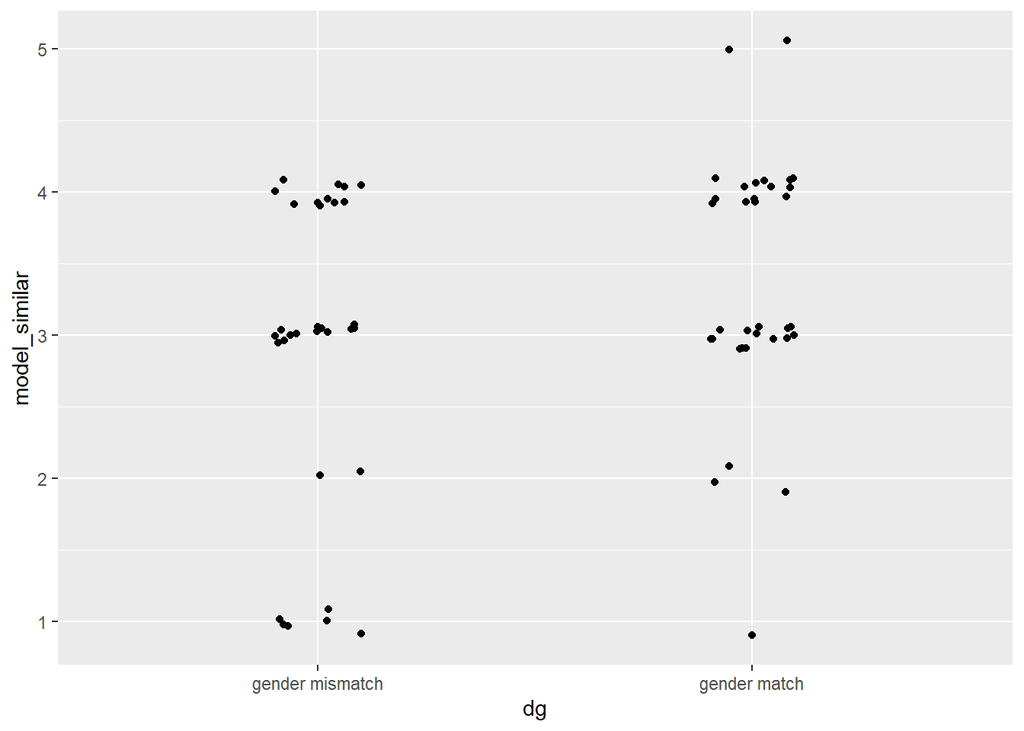

```r
dat %>%
  ggplot(aes(dg, model_similar)) +
  jitter
```

Did we ask students whether they thought the activity was difficult?

*Answer pilot type questions. Compare across outcomes variables with difference in responses, gender, race. People who persist and don’t persist.*

There is a moderate correlation between interest in CS and intention to take a CS course, indicating the existence of other contributing factors.

```r
chisq.test(dat$pre_att_cs, y = dat$post_att_cs)
```

```
##
##  Pearson's Chi-squared test
##
## data:  dat$pre_att_cs and dat$post_att_cs
## X-squared = 149.91, df = 81, p-value = 5.08e-06
```

```r
t.test(dat$pre_att_cs, y = dat$post_att_cs, paired = TRUE)
```

```
##
##  Paired t-test
##
## data:  dat$pre_att_cs and dat$post_att_cs
## t = 0.72675, df = 66, p-value = 0.4699
## alternative hypothesis: true difference in means is not equal to 0
## 95 percent confidence interval:
##  -0.1303912  0.2796449
## sample estimates:
## mean of the differences
##              0.07462687
```

There appears to be no significant difference between people’s interest in CS before the study and after the study.

## Race, class, and gender

Exploratory analyses based on survey data.

Does prior interest in CS correlate with demographics?

```r
dat_rac <- filter(dat, p_race != "unknown", p_race != "black", p_race != "")
```

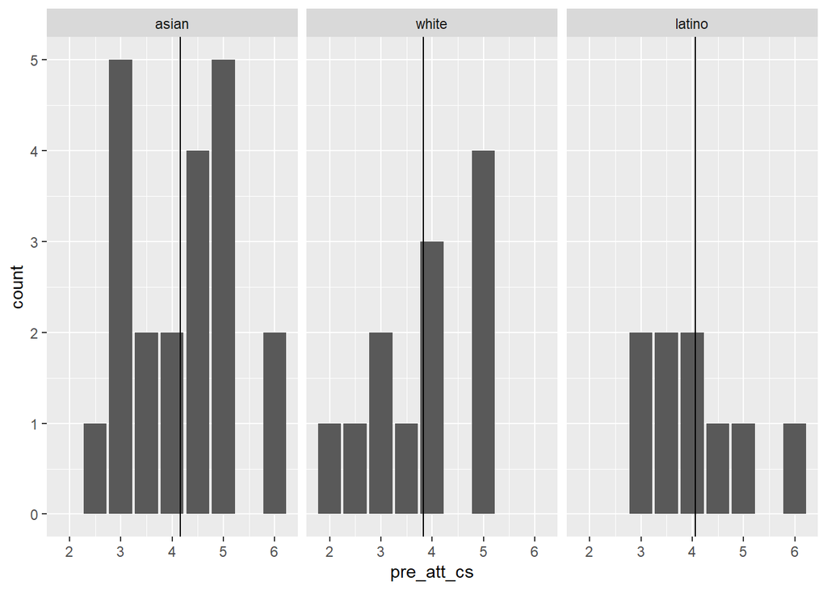

```r
vlines <- dat_rac %>%
  group_by(p_race) %>%
  summarize(avg = mean(as.numeric(pre_att_cs)))

dat_rac %>%
  ggplot(aes(pre_att_cs)) +
  geom_bar() +
  facet_wrap(~p_race) +
  geom_vline(data = vlines, aes(xintercept = avg))
```

```r
chisq.test(dat_rac$p_race, dat_rac$pre_att_cs)
```

```
##
##  Pearson's Chi-squared test
##
## data:  dat_rac$p_race and dat_rac$pre_att_cs
## X-squared = 10.4, df = 14, p-value = 0.7324
```

There was insufficient data to draw any particular conclusions.

```r
summary(aov(likely_cs_course ~ parents_fem * p_gender, data = dat))
```

```
##                      Df Sum Sq Mean Sq F value   Pr(>F)
## parents_fem           1  31.26  31.259  14.866 0.000274 ***
## p_gender              1   1.41   1.413   0.672 0.415390
## parents_fem:p_gender  1   0.01   0.014   0.007 0.934505
## Residuals            63 132.48   2.103
## ---
## Signif. codes:  0 '***' 0.001 '**' 0.01 '*' 0.05 '.' 0.1 ' ' 1
```

While parents’ gender-role beliefs strongly predict students’ likelihood of taking a CS course, there is no interaction between gender and gender-role beliefs, meaning that the relationship we see is likely caused by parents’ background which also causes them to have strong gender-role beliefs.

```r
summary(lm(persist ~ p_gender * p_race, data = dat_rac))
```

```
##
## Call:
## lm(formula = persist ~ p_gender * p_race, data = dat_rac)
##
## Residuals:
##    Min     1Q Median     3Q    Max
## -4.143 -1.975  0.550  2.100  4.000
##
## Coefficients:
##                             Estimate Std. Error t value Pr(>|t|)
## (Intercept)                   5.1429     0.9469   5.431 4.01e-06 ***
## p_genderfemale               -0.5000     1.1598  -0.431    0.669
## p_racewhite                  -2.6429     2.0088  -1.316    0.197
## p_racelatino                 -2.6429     2.0088  -1.316    0.197
## p_genderfemale:p_racewhite    2.9000     2.2608   1.283    0.208
## p_genderfemale:p_racelatino   1.0000     2.3195   0.431    0.669
## ---
## Signif. codes:  0 '***' 0.001 '**' 0.01 '*' 0.05 '.' 0.1 ' ' 1
##
## Residual standard error: 2.505 on 36 degrees of freedom
## Multiple R-squared:  0.1341, Adjusted R-squared:  0.01387
## F-statistic: 1.115 on 5 and 36 DF,  p-value: 0.3696
```

```r
summary(lm(post_belonging ~ p_gender * p_race, data = dat_rac))
```

```
##
## Call:
## lm(formula = post_belonging ~ p_gender * p_race, data = dat_rac)
##
## Residuals:
##     Min      1Q  Median      3Q     Max
## -2.3571 -1.0000 -0.1429  0.8036  2.6429
##
## Coefficients:
##                             Estimate Std. Error t value Pr(>|t|)
## (Intercept)                   3.1429     0.4932   6.373 2.21e-07 ***
## p_genderfemale                0.2143     0.6040   0.355    0.725
## p_racewhite                   0.3571     1.0461   0.341    0.735
## p_racelatino                 -0.6429     1.0461  -0.615    0.543
## p_genderfemale:p_racewhite   -0.2143     1.1774  -0.182    0.857
## p_genderfemale:p_racelatino  -0.1429     1.2080  -0.118    0.907
## ---
## Signif. codes:  0 '***' 0.001 '**' 0.01 '*' 0.05 '.' 0.1 ' ' 1
##
## Residual standard error: 1.305 on 36 degrees of freedom
## Multiple R-squared:  0.07808,    Adjusted R-squared:  -0.04996
## F-statistic: 0.6098 on 5 and 36 DF,  p-value: 0.6929
```

```r
summary(lm(fit_cs_skill ~ p_gender * p_race, data = dat_rac))
```

```
##
## Call:
## lm(formula = fit_cs_skill ~ p_gender * p_race, data = dat_rac)
##
## Residuals:
##     Min      1Q  Median      3Q     Max
## -1.9000 -0.9000 -0.1429  0.8214  2.1000
##
## Coefficients:
##                             Estimate Std. Error t value Pr(>|t|)
## (Intercept)                   3.2857     0.4231   7.766 3.34e-09 ***
## p_genderfemale                0.2857     0.5182   0.551   0.5848
## p_racewhite                  -0.2857     0.8976  -0.318   0.7521
## p_racelatino                 -1.7857     0.8976  -1.990   0.0543 .
## p_genderfemale:p_racewhite   -0.3857     1.0102  -0.382   0.7048
## p_genderfemale:p_racelatino   1.3571     1.0364   1.309   0.1987
## ---
## Signif. codes:  0 '***' 0.001 '**' 0.01 '*' 0.05 '.' 0.1 ' ' 1
##
## Residual standard error: 1.119 on 36 degrees of freedom
## Multiple R-squared:  0.162,  Adjusted R-squared:  0.04557
## F-statistic: 1.392 on 5 and 36 DF,  p-value: 0.2506
```

```r
summary(aov(pre_att_cs ~ p_gender * p_race + fit_cs_class, data = dat_rac))
```

```
##                 Df Sum Sq Mean Sq F value Pr(>F)
## p_gender         1   0.13   0.129   0.127  0.724
## p_race           2   0.98   0.492   0.484  0.620
## fit_cs_class     1   4.31   4.308   4.238  0.047 *
## p_gender:p_race  2   0.90   0.451   0.444  0.645
## Residuals       35  35.58   1.017
## ---
## Signif. codes:  0 '***' 0.001 '**' 0.01 '*' 0.05 '.' 0.1 ' ' 1
```

## Other explorations

I suspect that students will be more likely to drop off if they are taking the study late at night…

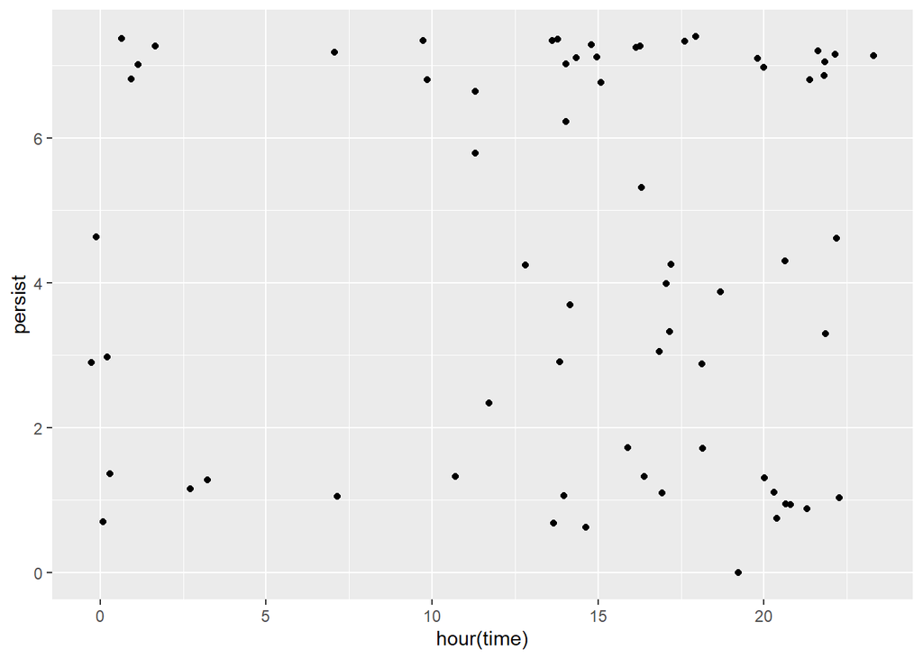

```r
dat %>%
  ggplot(aes(hour(time), persist)) +
  geom_jitter()
```

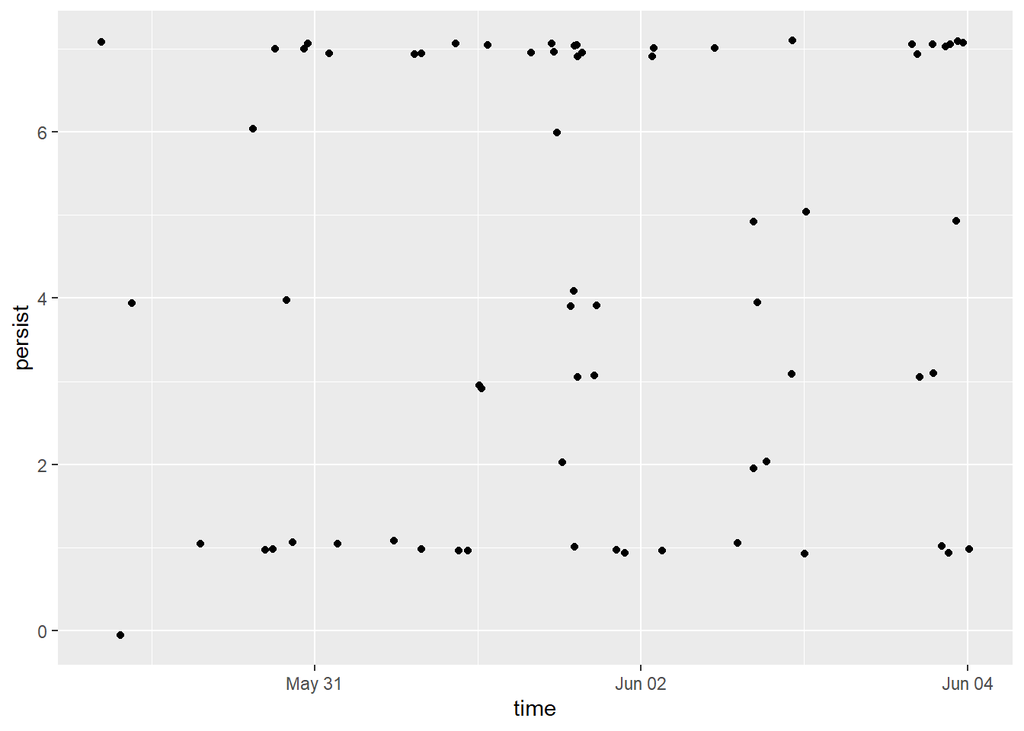

```r
dat %>%
  ggplot(aes(time, persist)) +
  geom_jitter(width = 0.1, height = 0.1)
```

*For students who have high stereotypic beliefs, are invested in CS, are given a non-matching and highly stereotypic (eg white/Asian male) role model: what do outcomes look like, compared to others?*

## Textual analysis

Using a new package called `tm` (text mining). Followed a [guide on text mining](http://www.sthda.com/english/wiki/text-mining-and-word-cloud-fundamentals-in-r-5-simple-steps-you-should-know).

I’ve noticed that what I really want are adjectives and nouns, not so much verbs or articles or prepositions.

*Try the tidytext package. Option to include negaters.*

*Look at gender differences.*

*Sentiment analysis. Positive/negative. Length of response as measure of engagement. Topic analysis?*

[Guide to text mining with tidytext](https://www.tidytextmining.com/)

Ideas: archival data, with computer science textbooks ? Lectures? Transcripts ?

Some overlap between response coding and text mining.

Pennebaker created Liwc for sentiment analysis in clinical context.

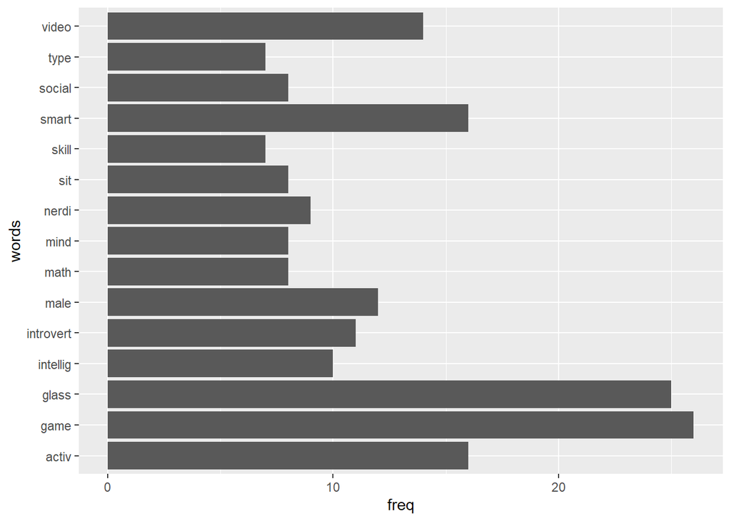

```r
resps <- dat %>%
  select(id, stereotype_txt) %>%
  filter(!is.na(stereotype_txt)) %>%
  mutate(doc_id = id,
         text = stereotype_txt)

text <- Corpus(DataframeSource(resps))
text <- text %>%
  tm_map(removeWords, stopwords("english")) %>%
  tm_map(content_transformer(tolower)) %>%
  tm_map(removePunctuation) %>%
  tm_map(stemDocument) %>%
  tm_map(removeWords, c("they", "peopl", "comput", "code", "program*",
                        "like", "interest", "good", "also", "probabl",
                        "person", "this", "use", "may", "someon", "spend",
                        "look", "might", "tend", "lot", "time", "enjoy",
                        "work", "wear", "stereotyp", "play", "think", "averag",
                        "frequent", "typic", "thing", "job", "imagin", "the",
                        "scienc"))

text_results <- as.matrix(TermDocumentMatrix(text))
text_results <- sort(rowSums(text_results), decreasing = TRUE)
text_results <- data.frame(words = names(text_results), freq = text_results) %>%
  arrange(desc(freq))

row.names(text_results) = 1:nrow(text_results)

text_results %>%
  arrange(desc(freq)) %>%
  head(15) %>%
  ggplot(aes(freq, words)) +
  geom_col()
```

While the above methods provide some interesting information, it is not very useful. A better approach would be to code responses by hand, noting where responses confirm stereotypes or serve to distance the speaker from computer scientists as a group. From the pilot data, I could create a codebook.

Note: look at previously published studies for codebooks and code these responses based on that (in a separate document).

*Apply for undergraduate research grants for Mechanical Turk* Wider age range and familiarity with technology UCLA is a special population Ask Ji about CalState LA Look into opening data collection in Sona over the summer

Compare the stereotype data with Mary’s study and mine

## Print output

Note: why is this so hard ???

```r
# t1 <- tbl_regression(dropoff_condition)
t2 <- tbl_regression(persist_condition)
t2
```

| **Characteristic** | **Beta** | **95% CI**<sup>1</sup> | **p-value** |
| --- | --- | --- | --- |
| age | -0.14 | -0.56, 0.29 | 0.5 |
| year | 1.0 | -0.15, 2.2 | 0.083 |
| gpa | -0.69 | -3.5, 2.1 | 0.6 |
| employ2 | -0.24 | -0.84, 0.37 | 0.4 |
| model_score | 0.09 | -0.92, 1.1 | 0.9 |
| model_race |  |  |  |
| white | — | — |  |
| black | -0.46 | -4.3, 3.3 | 0.8 |
| latino | 0.60 | -2.3, 3.5 | 0.7 |
| asian | 1.0 | -3.2, 5.3 | 0.6 |
| model_gender |  |  |  |
| male | — | — |  |
| female | -0.61 | -2.6, 1.4 | 0.5 |
| p_gender |  |  |  |
| male | — | — |  |
| female | 1.8 | -0.07, 3.6 | 0.059 |
| p_race |  |  |  |
| asian | — | — |  |
| white | -0.18 | -3.3, 3.0 | >0.9 |
| latino | -0.58 | -4.7, 3.6 | 0.8 |
| black | -0.63 | -5.9, 4.6 | 0.8 |
| unknown | -0.72 | -3.3, 1.9 | 0.6 |
| mom_cs | 0.94 | 0.22, 1.7 | 0.013 |
| dad_cs | 0.10 | -0.61, 0.82 | 0.8 |
| cs_xp | -0.43 | -2.1, 1.3 | 0.6 |
| pre_att_cs | 0.09 | -0.69, 0.88 | 0.8 |
| pre_useful_act | -0.14 | -1.3, 1.0 | 0.8 |
| pre_relevant_act | 0.79 | -0.24, 1.8 | 0.13 |
| major |  |  |  |
| human biology & society | — | — |  |
| other | -3.7 | -7.3, 0.00 | 0.050 |
| psychobiology | -3.1 | -6.8, 0.56 | 0.094 |
| microbiology | -2.7 | -8.2, 2.8 | 0.3 |
| cognitive science | -5.2 | -9.6, -0.90 | 0.019 |
| psychology | -4.0 | -8.3, 0.26 | 0.065 |
| neuroscience | -4.7 | -9.6, 0.24 | 0.062 |
| biology | -2.3 | -6.5, 2.0 | 0.3 |
| transfer | -1.0 | -3.7, 1.6 | 0.4 |
| dg |  |  |  |
| gender mismatch | — | — |  |
| gender match | -1.4 | -3.9, 1.2 | 0.3 |
| dr |  |  |  |
| race match | — | — |  |
| race mismatch | -0.65 | -4.2, 2.9 | 0.7 |
| dg * dr |  |  |  |
| gender match * race mismatch | 1.6 | -2.4, 5.7 | 0.4 |

<sup>*1*</sup> CI = Confidence Interval

```r
surv_tab <- tbl_regression(surv_mod2)
```

[output not shown]

```r
surv_tab
```

| **Characteristic** | **log(HR)**<sup>1</sup> | **95% CI**<sup>1</sup> | **p-value** |
| --- | --- | --- | --- |
| age | 0.10 | -0.18, 0.38 | 0.5 |
| year | -0.81 | -1.6, -0.01 | 0.046 |
| gpa | 0.88 | -1.1, 2.9 | 0.4 |
| model_score | -0.02 | -0.70, 0.67 | >0.9 |
| model_raceblack | 0.19 | -2.5, 2.9 | 0.9 |
| model_racelatino | -0.35 | -2.5, 1.8 | 0.8 |
| model_raceasian | -0.54 | -3.3, 2.2 | 0.7 |
| model_genderfemale | 0.57 | -0.70, 1.8 | 0.4 |
| p_genderfemale | -1.4 | -2.5, -0.28 | 0.014 |
| p_racewhite | 0.20 | -2.2, 2.6 | 0.9 |
| p_racelatino | 0.86 | -2.0, 3.7 | 0.6 |
| p_raceblack | 0.48 | -2.2, 3.2 | 0.7 |
| p_raceunknown | 0.86 | -0.65, 2.4 | 0.3 |
| mom_cs | -0.66 | -1.1, -0.21 | 0.004 |
| dad_cs | -0.09 | -0.48, 0.30 | 0.6 |
| cs_xp | 0.37 | -0.63, 1.4 | 0.5 |
| pre_att_cs | 0.01 | -0.42, 0.44 | >0.9 |
| pre_useful_act | 0.10 | -0.55, 0.75 | 0.8 |
| pre_relevant_act | -0.64 | -1.4, 0.10 | 0.090 |
| majorother | 18 | -7,398, 7,434 | >0.9 |
| majorpsychobiology | 18 | -7,398, 7,433 | >0.9 |
| majormicrobiology | 18 | -7,398, 7,434 | >0.9 |
| majorcognitive science | 19 | -7,397, 7,435 | >0.9 |
| majorpsychology | 19 | -7,397, 7,434 | >0.9 |
| majorneuroscience | 19 | -7,397, 7,435 | >0.9 |
| majorbiology | 17 | -7,399, 7,433 | >0.9 |
| transfer | 0.58 | -1.0, 2.1 | 0.5 |
| employ2 | 0.11 | -0.19, 0.40 | 0.5 |
| dggender match | 1.0 | -0.65, 2.7 | 0.2 |
| drrace mismatch | 0.55 | -1.9, 3.0 | 0.7 |
| dggender match:drrace mismatch | -1.4 | -4.3, 1.5 | 0.3 |

<sup>*1*</sup> HR = Hazard Ratio, CI = Confidence Interval

```r
# t4 <- tbl_regression(seconds_main)
#
# tbl_merge(tbls = list(t1, t2, t4),
#           tab_spanner = c("Dropoff after 1st activity", "Total activities completed", "Total time spent"))
#   #as_flex_table() %>%
#   #flextable::save_as_docx(path = "word.docx")
```

## Sources

[gtsummary](https://www.danieldsjoberg.com/gtsummary/)